# Simulação: Política de Limiar

# Teoria: Wavelet Shrinkage

Considere o problema de estimar a função desconhecida $f$, cujo modelo não paramétrico no formato vetorial é dado por:
$$\boldsymbol{y} = \boldsymbol{f} + \boldsymbol{e}$$
onde $\boldsymbol{y} = (y_1, \dots, y_n)'$ é o vetor de valores observados, $\boldsymbol{f} = (f(x_1), \dots, f(x_n))'$ é a função verdadeira e $\boldsymbol{e} = (e_1, \dots, e_n)'$ é o erro onde $e_i$, $i=1,\dots,n$, são variáveis aleatórias independentes e identicamente distribuídas (*i.i.d.*) com distribuição normal, média $0$ e variância $\sigma^2$, desconhecida. Tem-se por objetivo estimar a função $f$ e, para isso, é aplicado a DWT, representada por sua matriz $W$, de forma que:
$$\boldsymbol{d}^* = \boldsymbol{d} + \boldsymbol{\varepsilon}$$
com $\boldsymbol{d}^* = W \boldsymbol{y}$, $\boldsymbol{d} = W \boldsymbol{f}$ e $\boldsymbol{\varepsilon} = (\varepsilon_1,\dots, \varepsilon_n)' = W \boldsymbol{e}$. Além disso, as propriedades do erro $e_i$ são mantidas, logo, $\varepsilon_i \overset{i.i.d.}{\sim} \norm(0, \sigma^2)$, $i=1,\dots,n$. Portanto, o problema de estimar $f$ foi substituído por estimar os coeficientes de ondaletas $\boldsymbol d$ utilizando os coeficientes de ondaletas empíricos $\boldsymbol{d}^*$. A ideia do método consiste em utilizar a propriedade de *esparsidade* dos coeficientes de ondaletas, já que os coeficientes nulos estão associados à parte suave da função e os coeficientes não nulos associam-se às principais características da função, como descontinuidades, mudanças de comportamento, picos, entre outras. Logo, tem-se por objetivo encolher (ou zerar) os coeficientes de forma a reduzir o ruído aleatório $\varepsilon$. Para isso, é necessário escolher uma proposta para determinar o limiar $\lambda$.

## Universal Threshold

A proposta deste método para o cálculo do limiar é dada por
$$\lambda_u = \sigma\sqrt{2 \ln(n)}$$
onde $\sigma$ é estimado pelo MAD (*median absolute deviation*) dos coeficientes empíricos presentes na escala mais fina. Esse limiar leva a estimadores que subestimam $f$, já que apresenta uma tendência de aplicar o encolhimento em muitos coeficientes, principalmente em níveis de resolução mais finos.

## SURE Threshold

Este método utiliza como critério para a escolha do limiar $\lambda$ o valor que minimiza um estimador não viesado do risco de Stein (*Stein unbiased risk estimator*) $SURE(\lambda; \mathbf{y})$, dado por
$$SURE(\lambda; \mathbf{y}) = n - 2\#\{i:|y_i| \leq \lambda\} + \sum_{i}(\min\{|y_i|, \lambda\})^2$$
Além disso, vale notar que este método não funciona bem quando os coeficientes do sinal verdadeiro são muito esparsos.

## Validação Cruzada (CV)

O método de validação cruzada consiste em utilizar uma parcela dos dados para ajustar o modelo, enquanto que a parte restante é utilizada para avaliar sua adequação com o objetivo de estimar $f$. No caso das ondaletas a DWT precisa ser aplicada em um vetor diádico, portanto, faz-se necessária a utilização de um vetor com $2^J$ elementos. Logo, é utilizado metade das observações para ajuste do modelo e a outra metade na sua validação. O algorítimo do processo é dado por:

1. Remover as observações $y_i$ com subíndice ímpar do conjunto de dados, logo, tem-se $2^{J-1}$ observações, as quais devem ser reindexadas para $k=1, \dots, 2^{J-1}$;
2. Estimar a função $f$ por meio de $\hat f^{par}_\lambda$, utilizando um limiar particular $\lambda$ advindo dos dados reindexados;
3. Utilizar os dados retirados com subíndice ímpar para formar uma versão interpolada dos dados ímpares, dada por
   $$\bar{y}_k^{impar} = \begin{cases}
   (y_{2k - 1} + y_{2k + 1})/2 &,\; k=1,\dots, \frac{n}{2}-1\\
   (y_1 + y_{n-1})/2 &,\; k=\frac{n}{2}
   \end{cases}$$
4. De forma similar, deve-se obter $\hat f_\lambda^{impar}$ e $\bar y_k^{par}$ e calcular a estimativa do erro, dada por
   $$\hat M(\lambda) = \sum_k \left[ (\hat f_\lambda^{par}(y_k) - \bar y_k^{impar})^2 + (\hat f_\lambda^{impar}(y_k) - \bar y_k^{par})^2 \right]
   \tag{1}$$
5. Repetir o processo para uma faixa de valores de $\lambda$ e escolher o valor que minimize a Eq. 1.

## False Discovery Rate (FDR)

Neste método a escolha do limiar consiste em realizar testes de hipóteses de forma recursiva para cada nível de resolução e para cada coeficiente de ondaletas, testando se o coeficiente é zero (ruído) ou diferente de zero (sinal). O procedimento se dá por:

1. Calcular o p-valor $p_{jk}$ para cada coeficiente $d_{jk}$, testando $H_0:d_{jk} = 0$ contra $H_1:d_{jk} \neq 0$, isto é,
   $$p_{jk} = 2 \left( 1 - \Phi\left( \frac{|d^*_{jk}|}{\sigma} \right) \right)$$
2. Ordenar os p-valores obtidos e reindexá-los com base no seu valor, logo, $p_{(1)} \leq \dots \leq p_{(n)}$;
3. Seja $q$ o valor que representa o nível determinado para a taxa de coeficientes atribuídos erroneamente como não nulos e $i_0$ o maior $i$ tal que $p_{(i)} \leq \left(\frac{i}{m} \right)q$. Para este $i_0$ calcule o valor do limiar, dado por
   $$\lambda_{i_0} = \sigma \Phi^{-1} \left( 1 - \frac{p_{i_0}}{2} \right)$$

## Proposta Bayesiana sob Priori Logística (Sousa, 2020)

Priori atribuída:
$$\pi(d) = \alpha \delta_0 + (1 - \alpha) g(d; \tau)$$
onde $\alpha \in (0,1)$, $\delta_0$ é o delta de Dirac com massa em $0$ e $g(d; \tau)$ é a função densidade de probabilidade logística, dada por:
$$g(d; \tau) = \frac{\exp\left\{-\frac{d}{\tau}\right\}}{\tau \left( 1 + \exp\left\{-\frac{d}{\tau}\right\} \right)^2} \;\ind_\RR(d) \;, \spc \tau > 0$$

Regra de encolhimento:
$$\delta(d) = \frac{(1-\alpha) \int_\RR (\sigma u + d) g(\sigma u + d; \tau) \phi(u) \,du}{\frac{\alpha}{\sigma} \phi\left(\frac{d}{\sigma} \right) + (1-\alpha) \int_\RR g(\sigma u + d; \tau) \phi(u) \, du}$$

*Demonstração.* Considere nesta demonstração, para melhor denotar os termos, que $d=\theta$ e a substituição $u = \frac{\theta - d^*}{\sigma}$. Então,
$$\begin{align*}
\delta(\theta) &= \E(\theta \mid d^*) = \int_\RR \theta \,\pi(\theta\mid d^*) \,d\theta\\
&=\frac{\int_\RR \theta \,\pi(\theta) \LL(\theta\mid d^*) \,d\theta}{\int_\RR \pi(\theta) \LL(\theta\mid d^*) \,d\theta}\\
&=\frac{\int_\RR \theta [\alpha \delta_0 + (1 - \alpha) g(\theta; \tau)] \LL(\theta\mid d^*) \,d\theta}{\int_\RR [\alpha \delta_0 + (1 - \alpha) g(\theta; \tau)] \LL(\theta\mid d^*) \,d\theta}\\
&=\frac{\alpha\textstyle\int_\RR\theta \, \delta_0(\theta) \LL(\theta\mid d^*) \,d\theta + (1-\alpha) \int_\RR \theta \, g(\theta;\tau) \LL(\theta\mid d^*) \, d\theta}{\alpha \textstyle\int_\RR \delta_0(\theta) \LL(\theta\mid d^*) \, d\theta + (1-\alpha) \int_\RR g(\theta; \tau) \LL(\theta\mid d^*) \, d\theta}\\
&=\frac{(1-\alpha) \int_\RR \theta\, g(\theta; \tau) \frac{1}{\sqrt{2\pi}} \exp\left\{ -\frac{1}{2} \left( \frac{d^* - \theta}{\sigma} \right)^2 \right\} \frac{1}{\sigma} \, d\theta}
{\frac{\alpha}{\sigma\sqrt{2\pi}}\exp\left\{ -\frac{(d^*-0)^2}{2\sigma^2} \right\} + (1-\alpha) \int_\RR g(\theta; \tau) \frac{1}{\sqrt{2\pi}} \exp\left\{ -\frac{1}{2}\left(\frac{d^* - \theta}{\sigma}\right)^2 \right\} \frac{1}{\sigma} \,d\theta}\\
\delta(\theta) &= \frac{(1-\alpha) \int_\RR (\sigma u + d^*) g(\sigma u + d^*; \tau) \phi(u) \,du}{\frac{\alpha}{\sigma} \phi(\frac{d^*}{\sigma}) + (1 - \alpha) \int_\RR g(\sigma u + d^*; \tau) \phi(u) \,du}
\end{align*}$$

# Simulações

**Código**

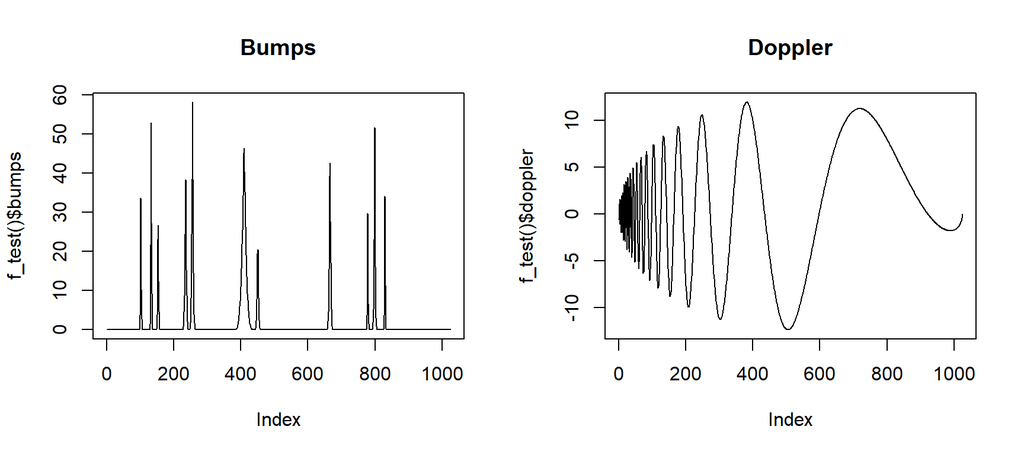

```r
require(fda.simu)

par(mfrow=c(1,2))
plot(f_test()$bumps, type='l', main='Bumps')
plot(f_test()$doppler, type='l', main='Doppler')
```

**Código**

```r
################
## Simulações ##
################
set.seed(282829)

require(future)
require(wavethresh)

plan(multisession, workers=6)

# funções verdadeiras
fun_comp_512 <- matrix(c(f_test(n=512)$bumps, f_test(n=512)$doppler), nrow=2, byrow=T)
fun_comp_2048 <- matrix(c(f_test(n=2048)$bumps, f_test(n=2048)$doppler), nrow=2, byrow=T)

#### snr=3 e n=512 ##############
simu_3_512_sure <- simu(fun_comp_512, rep=1000, n=15, snr=3, policy='sure')
simu_3_512_univ <- simu(fun_comp_512, rep=1000, n=15, snr=3, policy='universal')
simu_3_512_cv <- simu(fun_comp_512, rep=1000, n=15, snr=3, policy='cv')
simu_3_512_fdr <- simu(fun_comp_512, rep=1000, n=15, snr=3, policy='fdr')

#### snr=5 e n=512 ##############
simu_5_512_sure <- simu(fun_comp_512, rep=1000, n=15, snr=5, policy='sure')
simu_5_512_univ <- simu(fun_comp_512, rep=1000, n=15, snr=5, policy='universal')
simu_5_512_cv <- simu(fun_comp_512, rep=1000, n=15, snr=5, policy='cv')
simu_5_512_fdr <- simu(fun_comp_512, rep=1000, n=15, snr=5, policy='fdr')

#### snr=9 e n=512 ##############
simu_9_512_sure <- simu(fun_comp_512, rep=1000, n=15, snr=9, policy='sure')
simu_9_512_univ <- simu(fun_comp_512, rep=1000, n=15, snr=9, policy='universal')
simu_9_512_cv <- simu(fun_comp_512, rep=1000, n=15, snr=9, policy='cv')
simu_9_512_fdr <- simu(fun_comp_512, rep=1000, n=15, snr=9, policy='fdr')


#### snr=3 e n=2048 ##############
simu_3_2048_sure <- simu(fun_comp_2048, rep=1000, n=15, snr=3, policy='sure')
simu_3_2048_univ <- simu(fun_comp_2048, rep=1000, n=15, snr=3, policy='universal')
simu_3_2048_cv <- simu(fun_comp_2048, rep=1000, n=15, snr=3, policy='cv')
simu_3_2048_fdr <- simu(fun_comp_2048, rep=1000, n=15, snr=3, policy='fdr')

#### snr=5 e n=2048 ##############
simu_5_2048_sure <- simu(fun_comp_2048, rep=1000, n=15, snr=5, policy='sure')
simu_5_2048_univ <- simu(fun_comp_2048, rep=1000, n=15, snr=5, policy='universal')
simu_5_2048_cv <- simu(fun_comp_2048, rep=1000, n=15, snr=5, policy='cv')
simu_5_2048_fdr <- simu(fun_comp_2048, rep=1000, n=15, snr=5, policy='fdr')

#### snr=9 e n=2048 ##############
simu_9_2048_sure <- simu(fun_comp_2048, rep=1000, n=15, snr=5, policy='sure')
simu_9_2048_univ <- simu(fun_comp_2048, rep=1000, n=15, snr=5, policy='universal')
simu_9_2048_cv <- simu(fun_comp_2048, rep=1000, n=15, snr=5, policy='cv')
simu_9_2048_fdr <- simu(fun_comp_2048, rep=1000, n=15, snr=5, policy='fdr')
```

**Média (desvio padrão) para o erro da função Bumps**

[output not shown]

**Média (desvio padrão) para o erro da função Doppler**

[output not shown]

**Média (desvio padrão) para o erro geral**

[output not shown]

**Código**

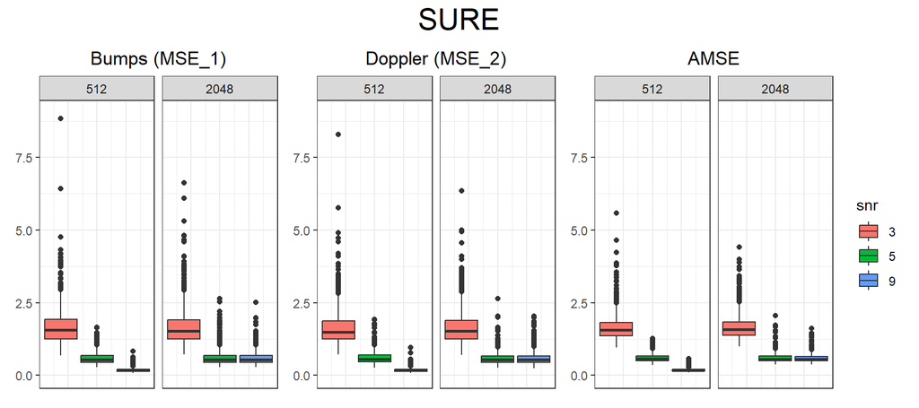

```r
require(ggplot2)
require(magrittr)
require(patchwork)

load('simulacoes.RData')

# sapply(simu_9_2048_fdr, function(x) round(c('Média'=mean(x), 'SD'= sd(x)), 4))
#
# dados <- list(simu_3_512_sure, simu_3_512_univ, simu_3_512_cv, simu_3_512_fdr,
#               simu_5_512_sure, simu_5_512_univ, simu_5_512_cv, simu_5_512_fdr,
#               simu_9_512_sure, simu_9_512_univ, simu_9_512_cv, simu_9_512_fdr,
#               simu_3_2048_sure, simu_3_2048_univ, simu_3_2048_cv,
#               simu_3_2048_fdr, simu_5_2048_sure, simu_5_2048_univ,
#               simu_5_2048_cv, simu_5_2048_fdr, simu_9_2048_sure,
#               simu_9_2048_univ, simu_9_2048_cv, simu_9_2048_fdr
# )
#
# names(dados) <- c('simu_3_512_sure', 'simu_3_512_univ', 'simu_3_512_cv',
#                   'simu_3_512_fdr', 'simu_5_512_sure', 'simu_5_512_univ',
#                   'simu_5_512_cv', 'simu_5_512_fdr', 'simu_9_512_sure',
#                   'simu_9_512_univ', 'simu_9_512_cv', 'simu_9_512_fdr',
#                   'simu_3_2048_sure', 'simu_3_2048_univ', 'simu_3_2048_cv',
#                   'simu_3_2048_fdr', 'simu_5_2048_sure', 'simu_5_2048_univ',
#                   'simu_5_2048_cv', 'simu_5_2048_fdr', 'simu_9_2048_sure',
#                   'simu_9_2048_univ', 'simu_9_2048_cv', 'simu_9_2048_fdr')


# tema geral para os gráficos
tema <- theme_bw() +
  theme(axis.text.x=element_blank(),
        axis.ticks.x=element_blank(),
        plot.title = element_text(hjust=0.5))

# gráficos
sure <- rbind(simu_3_512_sure, simu_5_512_sure, simu_9_512_sure,
              simu_3_2048_sure, simu_5_2048_sure, simu_9_2048_sure)
sure$snr <- factor(rep(c(3, 5, 9), 2, each=1000))
sure$n <- rep(c(512, 2048), each=3000)

(sure %>%
  ggplot(aes(y=MSE_1, fill=snr)) +
  geom_boxplot() +
  facet_grid(~ n) +
  labs(title='Bumps (MSE_1)', y=NULL) +
  scale_y_continuous(limits=c(0,9)) +
  guides(fill='none') +
  tema
) + (
sure %>%
  ggplot(aes(y=MSE_2, fill=snr)) +
  geom_boxplot() +
  facet_grid(~ n) +
  labs(title='Doppler (MSE_2)', y=NULL) +
  scale_y_continuous(limits=c(0,9)) +
  guides(fill='none') +
  tema
) + (
sure %>%
  ggplot(aes(y=AMSE, fill=snr)) +
  geom_boxplot() +
  facet_grid(~ n) +
  labs(title='AMSE', y=NULL) +
  scale_y_continuous(limits=c(0,9)) +
  tema
) +
  plot_annotation(title='SURE',
    theme=theme(plot.title = element_text(hjust=0.5, size=21)))
```

**Código**

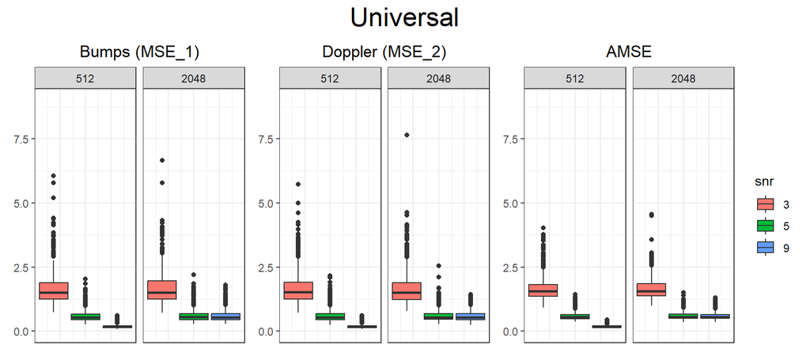

```r
univ <- rbind(simu_3_512_univ, simu_5_512_univ, simu_9_512_univ,
              simu_3_2048_univ, simu_5_2048_univ, simu_9_2048_univ)
univ$snr <- factor(rep(c(3, 5, 9), 2, each=1000))
univ$n <- rep(c(512, 2048), each=3000)

(univ %>%
  ggplot(aes(y=MSE_1, fill=snr)) +
  geom_boxplot() +
  facet_grid(~ n) +
  labs(title='Bumps (MSE_1)', y=NULL) +
  scale_y_continuous(limits=c(0,9)) +
  guides(fill='none') +
  tema
) + (
univ %>%
  ggplot(aes(y=MSE_2, fill=snr)) +
  geom_boxplot() +
  facet_grid(~ n) +
  labs(title='Doppler (MSE_2)', y=NULL) +
  scale_y_continuous(limits=c(0,9)) +
  guides(fill='none') +
  tema
) + (
univ %>%
  ggplot(aes(y=AMSE, fill=snr)) +
  geom_boxplot() +
  facet_grid(~ n) +
  labs(title='AMSE', y=NULL) +
  scale_y_continuous(limits=c(0,9)) +
  tema
) +
  plot_annotation(title='Universal',
    theme=theme(plot.title = element_text(hjust=0.5, size=21)))
```

**Código**

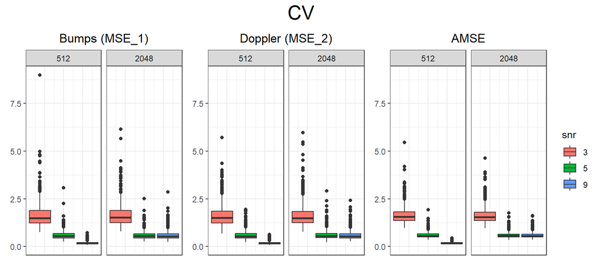

```r
cv <- rbind(simu_3_512_cv, simu_5_512_cv, simu_9_512_cv,
              simu_3_2048_cv, simu_5_2048_cv, simu_9_2048_cv)
cv$snr <- factor(rep(c(3, 5, 9), 2, each=1000))
cv$n <- rep(c(512, 2048), each=3000)

(cv %>%
  ggplot(aes(y=MSE_1, fill=snr)) +
  geom_boxplot() +
  facet_grid(~ n) +
  labs(title='Bumps (MSE_1)', y=NULL) +
  scale_y_continuous(limits=c(0,9)) +
  guides(fill='none') +
  tema
) + (
cv %>%
  ggplot(aes(y=MSE_2, fill=snr)) +
  geom_boxplot() +
  facet_grid(~ n) +
  labs(title='Doppler (MSE_2)', y=NULL) +
  scale_y_continuous(limits=c(0,9)) +
  guides(fill='none') +
  tema
) + (
cv %>%
  ggplot(aes(y=AMSE, fill=snr)) +
  geom_boxplot() +
  facet_grid(~ n) +
  labs(title='AMSE', y=NULL) +
  scale_y_continuous(limits=c(0,9)) +
  tema
) +
  plot_annotation(title='CV',
    theme=theme(plot.title = element_text(hjust=0.5, size=21)))
```

**Código**

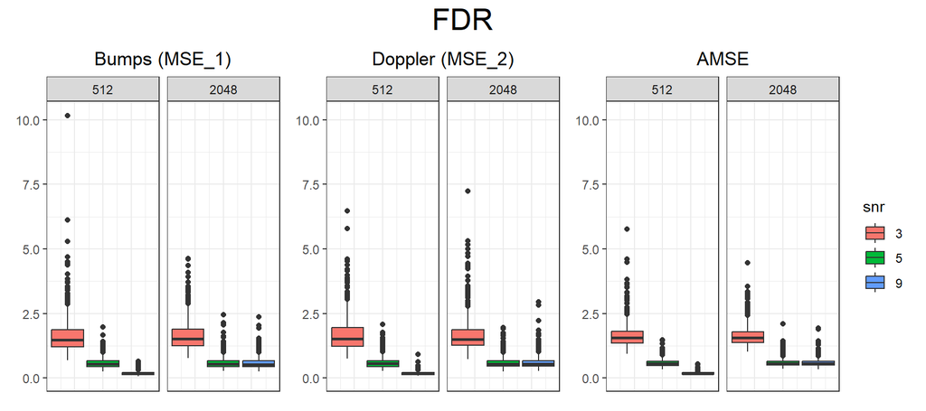

```r
fdr <- rbind(simu_3_512_fdr, simu_5_512_fdr, simu_9_512_fdr,
              simu_3_2048_fdr, simu_5_2048_fdr, simu_9_2048_fdr)
fdr$snr <- factor(rep(c(3, 5, 9), 2, each=1000))
fdr$n <- rep(c(512, 2048), each=3000)

(fdr %>%
  ggplot(aes(y=MSE_1, fill=snr)) +
  geom_boxplot() +
  facet_grid(~ n) +
  labs(title='Bumps (MSE_1)', y=NULL) +
  scale_y_continuous(limits=c(0,10.2)) +
  guides(fill='none') +
  tema
) + (
fdr %>%
  ggplot(aes(y=MSE_2, fill=snr)) +
  geom_boxplot() +
  facet_grid(~ n) +
  labs(title='Doppler (MSE_2)', y=NULL) +
  scale_y_continuous(limits=c(0,10.2)) +
  guides(fill='none') +
  tema
) + (
fdr %>%
  ggplot(aes(y=AMSE, fill=snr)) +
  geom_boxplot() +
  facet_grid(~ n) +
  labs(title='AMSE', y=NULL) +
  scale_y_continuous(limits=c(0,10.2)) +
  tema
) +
  plot_annotation(title='FDR',
    theme=theme(plot.title = element_text(hjust=0.5, size=21)))
```

# Referências

- Nason, G.P. (2008). *Wavelet Methods in Statistics with R*. Springer.

- Sousa, A.R.S. (2020). Bayesian wavelet shrinkage with logistic prior. *Communications in Statistics - Simulation and Computation*, DOI: 10.1080/03610918.2020.1747076.

# Funções do Pacote Utilizadas

```
------ simu ------------------------------
```

```
function(fun_comp, rep, n=10, snr, policy='sure', filter.number=10) {
  future_map(1:rep, ~{
    # gerando amostra
    y1 <- runif(n)  # pesos da curva 1
    y2 <- 1 - y1    # pesos da curva 2
    y <- matrix(c(y1, y2), nrow=2, byrow=T)
    fun_agr <- matrix(0, n, ncol(fun_comp))  # pre-alocando memoria
    for (i in 1:n) fun_agr[i,] <- y1[i]*fun_comp[1,] + y2[i]*fun_comp[2,] +
      rnorm(ncol(fun_comp), 0, 7/snr)

    # wavelets
    alpha <- desagrega(fun_agr, y, policy=policy, filter.number=filter.number)

    # calculando erro
    MSE_1 <- sum((alpha[,1] - fun_comp[1,])^2) / ncol(fun_comp)  # MSE da fç componente 1
    MSE_2 <- sum((alpha[,2] - fun_comp[2,])^2) / ncol(fun_comp)  # MSE da fç componente 2
    AMSE <- (MSE_1 + MSE_2) / 2
    data.frame('MSE_1'=MSE_1, 'MSE_2'=MSE_2, 'AMSE'=AMSE)
  }, .options=furrr_options(seed=TRUE), .progress=T) |>
    do.call(rbind, args = _)
}
<bytecode: 0x000001be2936c418>
<environment: namespace:fda.simu>
```

```
------ logis_shrink ------------------------------
```

```
function(d, a, s, t) {
  u <- rnorm(10000)
  delta <- vector(length(d), mode='double')
  for(i in 1:length(d)) {
    logis <- dlogis(s*u + d[i], scale=t)
    int1 <- mean((s*u + d[i]) * logis)
    int2 <- mean(logis)
    delta[i] <- (1-a) * int1/(a * dnorm(d[i], sd=s)/s + (1-a) * int2)
  }
  return(delta)
}
<bytecode: 0x000001be24a90f40>
<environment: namespace:fda.simu>
```

```
------ f_test ------------------------------
```

```
function(n=1024, signal=7, snr=7, noise=FALSE)
{
  x <- seq(1, n)/n
  t <- c(0.1, 0.13, 0.15, 0.23, 0.25, 0.4, 0.44, 0.65, 0.76, 0.78, 0.81)

  # Bumps
  h.bumps <- c(4, 5, 3, 4, 5, 4.2, 2.1, 4.3, 3.1, 5.1, 4.2)
  w <- c(0.005, 0.005, 0.006, 0.01, 0.01, 0.03, 0.01, 0.01, 0.005, 0.008, 0.005)
  bumps <- rep(0, n)
  for (i in seq(1, length(h.bumps))) {
    bumps <- bumps + h.bumps[i] * pmax(0, (1 - abs((x - t[i])/w[i])))^4
  }

  # Blocks
  h.blocks <- c(4, -5, 3, -4, 5, -4.2, 2.1, 4.3, -3.1, 2.1, -4.2)
  blocks <- rep(0, n)
  for (i in seq(1, length(h.blocks))) {
    blocks <- blocks + (h.blocks[i] * (1 + sign(x - t[i])))/2
  }

  # Doppler
  doppler <- sqrt(x * (1 - x)) * sin(2 * pi * (1 - 0.05) / (x + 0.05))  # wavethresh
  # doppler <- sqrt(x * (1 - x)) * sin(2 * pi * (1 + 0.05) / (x + 0.05))  # Alex

  # Heavisine
  heavisine <- 4 * sin(4 * pi * x) - sign(x - 0.3) - sign(0.72 - x)

  # Logit
  logit <- 1/(1 + exp(-20 * (x - 0.5)))

  # SpaHet
  spahet <- sqrt(x * (1 - x)) * sin(2 * pi * (1 + 2^(-0.6))/(x + 2^(-0.6)))

  # example.1 - piecewise polynomial
  example <- rep(0, length(x))
  i1 <- x <= 0.5
  i2 <- (x > 0.5) & (x <= 0.75)
  i3 <- x > 0.75
  example[i1] <- -16 * x[i1]^3 + 12 * x[i1]^2
  example[i2] <- (x[i2] * (16 * x[i2]^2 - 40 * x[i2] + 28))/3 - 1.5
```

[output cut: 15 more lines]

```
                   'doppler'=doppler + rnorm(n, 0, signal/snr),
                   'heavisine'=heavisine + rnorm(n, 0, signal/snr),
                   'logit'=logit + rnorm(n, 0, signal/snr),
                   'spahet'=spahet + rnorm(n, 0, signal/snr),
                   'example'=example + rnorm(length(example), 0, signal/snr))
  }
  else {
    result <- list('x'=x, 'bumps'=bumps, 'blocks'=blocks, 'doppler'=doppler,
                   'heavisine'=heavisine, 'logit'=logit, 'spahet'=spahet,
                   'example'=example)
  }
  return(result)
}
<bytecode: 0x000001be24853260>
<environment: namespace:fda.simu>
```